# WQS Test of Selection – rrBlup Style

Timothy M. Beissinger

June 6, 2016

Data from Lorenz, 2015 (G3) will be re-visited to test the hypothesis that the reason selection mapping and GWAS yielded no results, despite moderate to high heritabilities and phenotypic change, was because the selected traits were highly quantitative. To do this, allelic effects will be estimated using GWAS and allele frequency change from cycle 2 to cycle 5 will be computed. Then, the sum of frequency change multiplied by effect size will be computed. If effects and frequency changes are related, this sum should be non-zero and in the direction that the trait was selected. A permutation test will be conducted to test for significance.

### Data loading and prep

First we read in the Genotypes. There are not many markers here, and the reason why not is not explained in the paper… Something to ask Aaron about.

```r
setwd("/home/beissinger/Documents/WQS_Prediction/Frequency_change/")
wqsGeno <- read.csv('../../WQS/DATA/genoWQS_randImp.csv',header=T,stringsAsFactors=F)
```

Now we’ll import the map.

```r
wqsMap <- read.csv('../../WQS/DATA/wqsMap_randImp.csv',stringsAsFactors=F)
```

Gapit cannot work with non-integer chromosomes. Remove those labeled “0”

```r
remMap <- which(wqsMap$Chromosome == 0)
remGeno <- remMap+1

wqsGeno<-wqsGeno[,-remGeno]
wqsMap<-wqsMap[-remMap,]
```

Now split individuals into different data frames according to their cycle

```r
names(wqsGeno)[1] <- "Taxa"
CycleIndicator <- as.numeric(unlist(strsplit(wqsGeno$Taxa,split="_C"))[seq(2,2*nrow(wqsGeno),2)])

Cycle0 <- wqsGeno[which(CycleIndicator == 0),]
Cycle1 <- wqsGeno[which(CycleIndicator == 1),]
Cycle2 <- wqsGeno[which(CycleIndicator == 2),]
Cycle3 <- wqsGeno[which(CycleIndicator == 3),]
Cycle4 <- wqsGeno[which(CycleIndicator == 4),]
Cycle5 <- wqsGeno[which(CycleIndicator == 5),]
CycleList <- list(Cycle0,Cycle1,Cycle2,Cycle3,Cycle4,Cycle5)
```

### Analysis

The next step is to calculate the allele frequency at each cycle.

```r
frequencies<-matrix(nrow=ncol(wqsGeno)-1,ncol=6)
for(i in 1:6){
frequencies[,i] <- colMeans(CycleList[[i]][,-1],na.rm=T)/2
}
frequencies <- as.data.frame(frequencies)
names(frequencies) <- c("Cycle0","Cycle1","Cycle2","Cycle3","Cycle4","Cycle5")
```

Now load in effects estimates.

```r
adf <- read.csv("../GWAS_effects/GWAS_adf/GAPIT..Intercept.BLUP.Allelic_Effect_Estimates.csv")
ndf <- read.csv("../GWAS_effects/GWAS_ndf/GAPIT..Intercept.BLUP.Allelic_Effect_Estimates.csv")
ivd <- read.csv("../GWAS_effects/GWAS_ivd/GAPIT..Intercept.BLUP.Allelic_Effect_Estimates.csv")
cp <- read.csv("../GWAS_effects/GWAS_cp/GAPIT..Intercept.BLUP.Allelic_Effect_Estimates.csv")
starch <- read.csv("../GWAS_effects/GWAS_starch/GAPIT..Intercept.BLUP.Allelic_Effect_Estimates.csv")
yield<- read.csv("../GWAS_effects/GWAS_yield/GAPIT..Intercept.BLUP.Allelic_Effect_Estimates.csv")
drymat<- read.csv("../GWAS_effects/GWAS_drymat/GAPIT..Intercept.BLUP.Allelic_Effect_Estimates.csv")
```

Now compute allele frequency change from cycle 2 to 5 and make a histogram

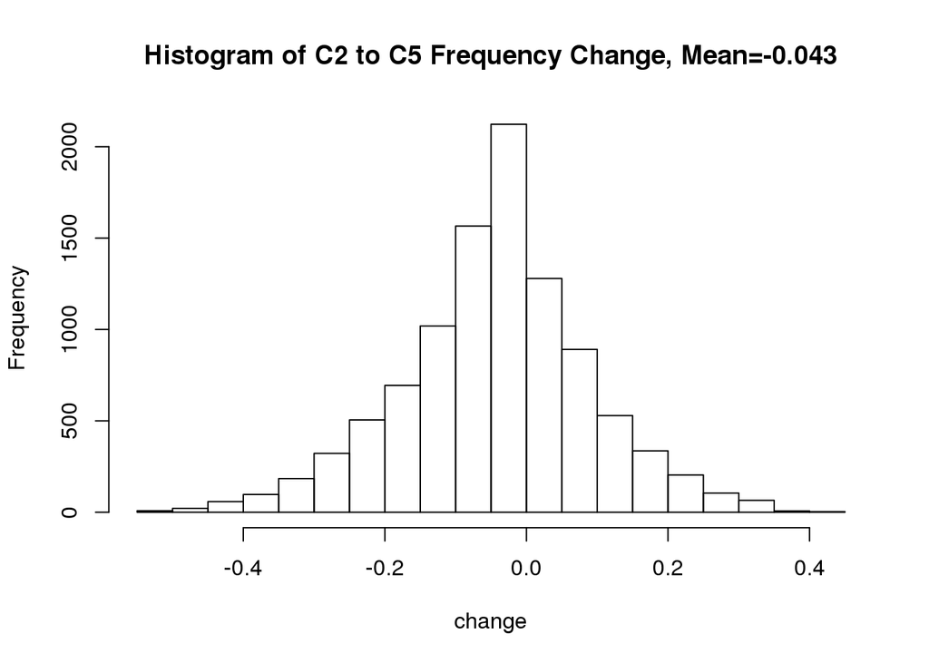

```r
change<-frequencies$Cycle5-frequencies$Cycle2
hist(change,main=paste("Histogram of C2 to C5 Frequency Change, Mean=",round(mean(change,na.rm=T),digits=3),sep=""))
```

Now compute the sum of frequency*change

```r
adf_result <- sum(change*adf$Allelic.Effect.Estimate,na.rm=T)
ndf_result <- sum(change*ndf$Allelic.Effect.Estimate,na.rm=T)
ivd_result <- sum(change*ivd$Allelic.Effect.Estimate,na.rm=T)
cp_result <- sum(change*cp$Allelic.Effect.Estimate,na.rm=T)
starch_result <- sum(change*starch$Allelic.Effect.Estimate,na.rm=T)
yield_result <- sum(change*yield$Allelic.Effect.Estimate,na.rm=T)
drymat_result <- sum(change*drymat$Allelic.Effect.Estimate,na.rm=T)
```

Now do a quick permutation test. Are there reason that permuting SNPs is not a valid approach? (I can’t think of any at the moment)

```r
adf_test<-c(); ndf_test<-c(); ivd_test<-c(); cp_test<-c(); starch_test<-c(); yield_test<-c(); drymat_test<-c()
for(i in 1:1000){
  boot <- sample(change,length(change),replace=T)
  adf_test[i]<-sum(boot*adf$Allelic.Effect.Estimate,na.rm=T)
  ndf_test[i]<-sum(boot*ndf$Allelic.Effect.Estimate,na.rm=T)
  ivd_test[i]<-sum(boot*ivd$Allelic.Effect.Estimate,na.rm=T)
  cp_test[i]<-sum(boot*cp$Allelic.Effect.Estimate,na.rm=T)
  starch_test[i]<-sum(boot*starch$Allelic.Effect.Estimate,na.rm=T)
  yield_test[i]<-sum(boot*yield$Allelic.Effect.Estimate,na.rm=T)
  drymat_test[i]<-sum(boot*drymat$Allelic.Effect.Estimate,na.rm=T)
  }
```

### Results

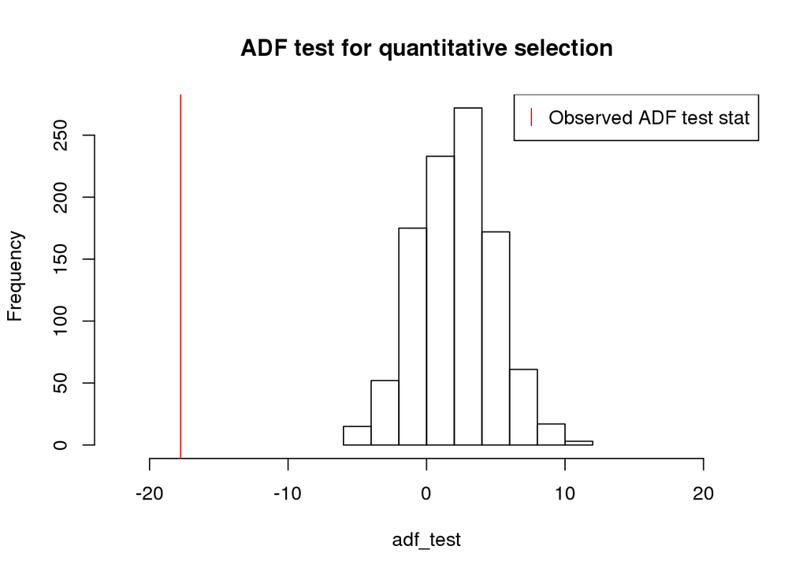

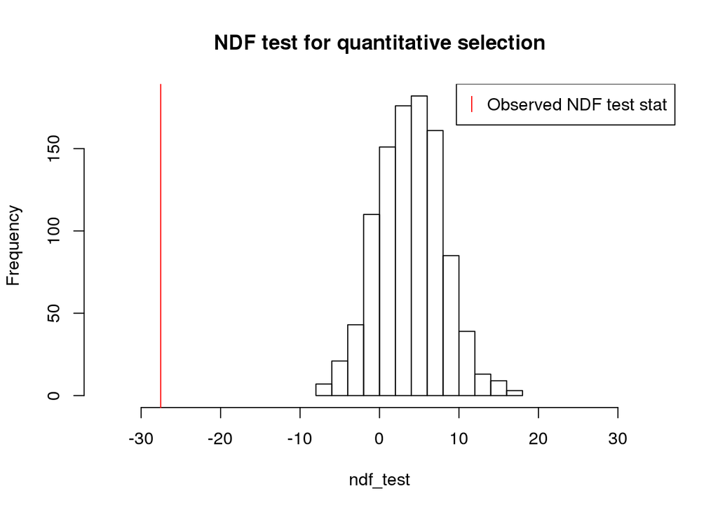

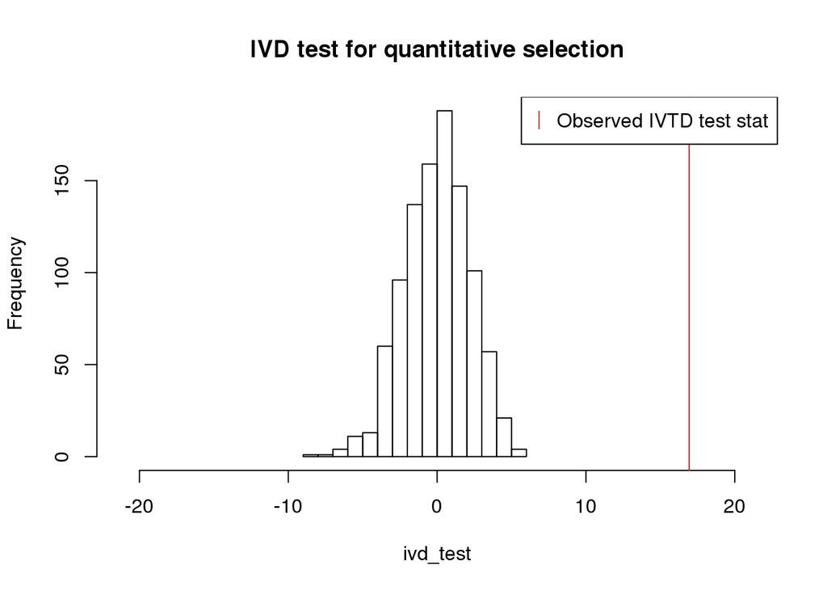

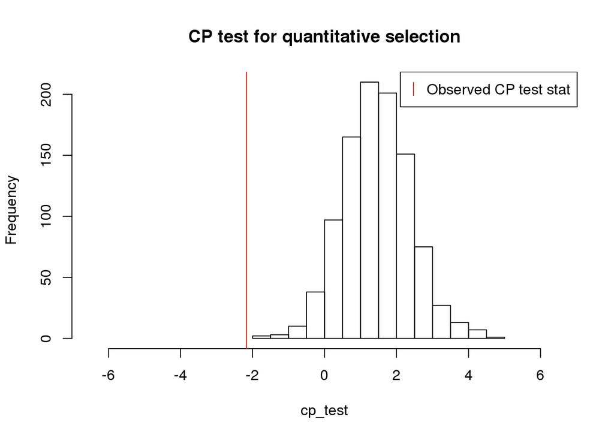

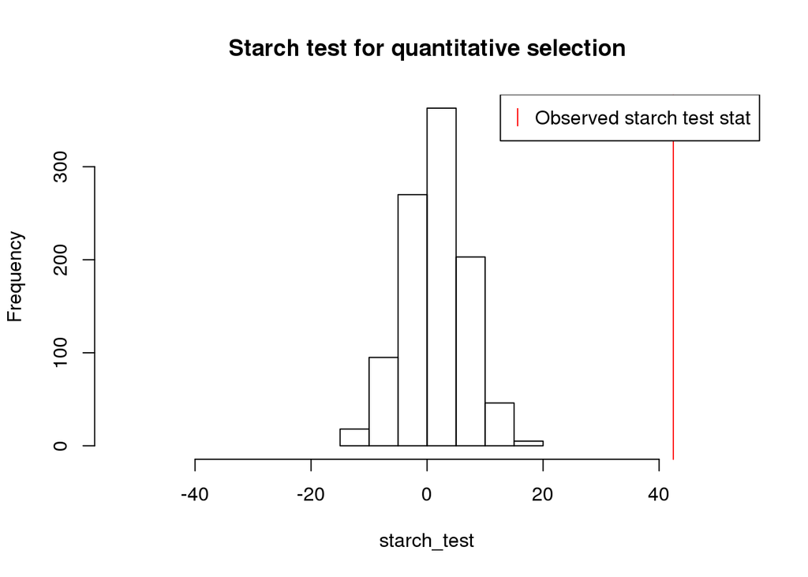

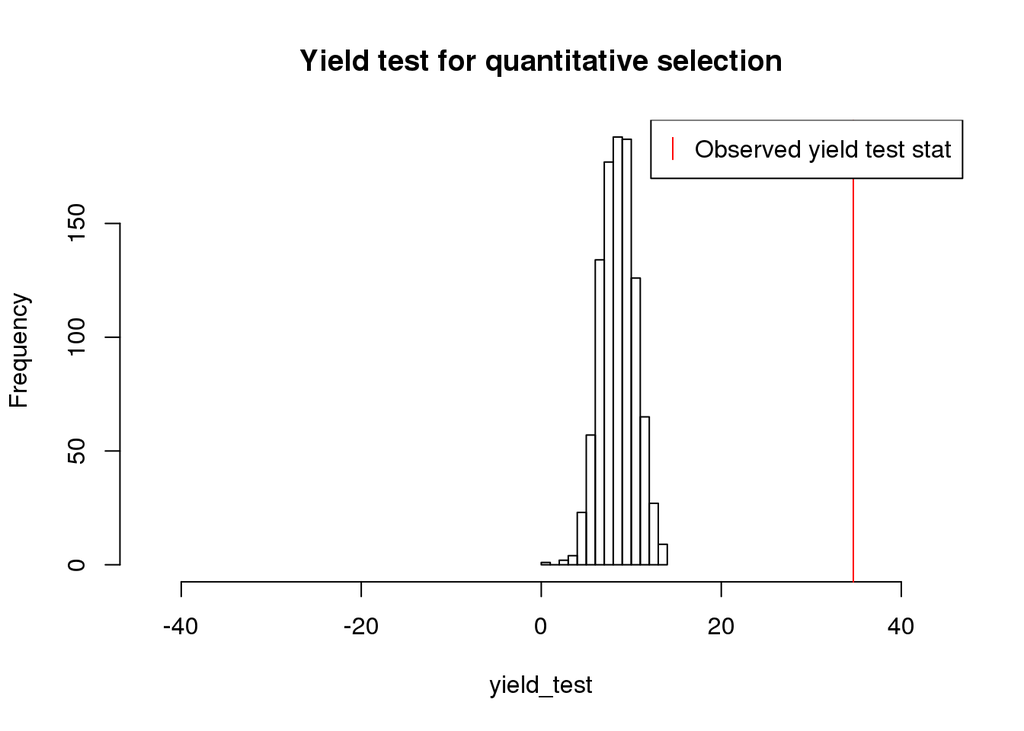

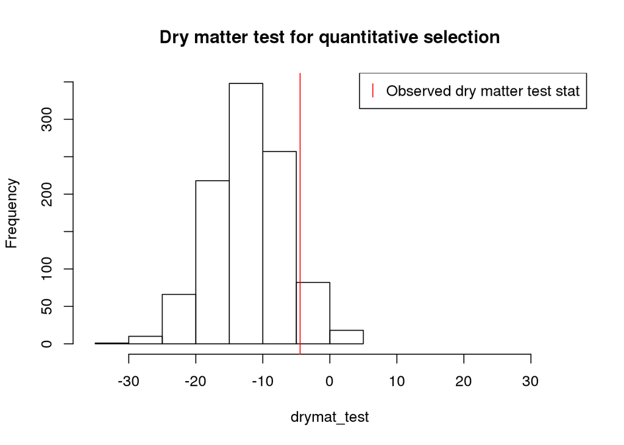

Test the correlation between trait allelic effects and frequency change.

```r
cor.test(change,adf$Allelic.Effect.Estimate,na.rm=T)
```

```
##
##  Pearson's product-moment correlation
##
## data:  change and adf$Allelic.Effect.Estimate
## t = -7.0467, df = 9844, p-value = 1.955e-12
## alternative hypothesis: true correlation is not equal to 0
## 95 percent confidence interval:
##  -0.09047083 -0.05116350
## sample estimates:
##         cor
## -0.07084467
```

```r
cor.test(change,ndf$Allelic.Effect.Estimate,na.rm=T)
```

```
##
##  Pearson's product-moment correlation
##
## data:  change and ndf$Allelic.Effect.Estimate
## t = -7.7174, df = 9844, p-value = 1.303e-14
## alternative hypothesis: true correlation is not equal to 0
## 95 percent confidence interval:
##  -0.09715257 -0.05788453
## sample estimates:
##         cor
## -0.07754863
```

```r
cor.test(change,ivd$Allelic.Effect.Estimate,na.rm=T)
```

```
##
##  Pearson's product-moment correlation
##
## data:  change and ivd$Allelic.Effect.Estimate
## t = 7.8568, df = 9844, p-value = 4.354e-15
## alternative hypothesis: true correlation is not equal to 0
## 95 percent confidence interval:
##  0.05928036 0.09853980
## sample estimates:
##        cor
## 0.07894069
```

```r
cor.test(change,cp$Allelic.Effect.Estimate,na.rm=T)
```

```
##
##  Pearson's product-moment correlation
##
## data:  change and cp$Allelic.Effect.Estimate
## t = -3.8875, df = 9844, p-value = 0.000102
## alternative hypothesis: true correlation is not equal to 0
## 95 percent confidence interval:
##  -0.05885872 -0.01941373
## sample estimates:
##         cor
## -0.03915148
```

```r
cor.test(change,starch$Allelic.Effect.Estimate,na.rm=T)
```

```
##
##  Pearson's product-moment correlation
##
## data:  change and starch$Allelic.Effect.Estimate
## t = 7.6407, df = 9844, p-value = 2.362e-14
## alternative hypothesis: true correlation is not equal to 0
## 95 percent confidence interval:
##  0.05711675 0.09638945
## sample estimates:
##        cor
## 0.07678288
```

```r
cor.test(change,yield$Allelic.Effect.Estimate,na.rm=T)
```

```
##
##  Pearson's product-moment correlation
##
## data:  change and yield$Allelic.Effect.Estimate
## t = 13.389, df = 9578, p-value < 2.2e-16
## alternative hypothesis: true correlation is not equal to 0
## 95 percent confidence interval:
##  0.1158355 0.1551502
## sample estimates:
##       cor
## 0.1355462
```

```r
cor.test(change,drymat$Allelic.Effect.Estimate,na.rm=T)
```

```
##
##  Pearson's product-moment correlation
##
## data:  change and drymat$Allelic.Effect.Estimate
## t = 1.4822, df = 9861, p-value = 0.1383
## alternative hypothesis: true correlation is not equal to 0
## 95 percent confidence interval:
##  -0.004813112  0.034649564
## sample estimates:
##        cor
## 0.01492404
```

Now make pretty cumulative plots for each trait, like Jochen did with milk yield.

```r
adf$Allelic.Effect.Estimate[which(is.na(adf$Allelic.Effect.Estimate))] <- 0### Remove NAs
ndf$Allelic.Effect.Estimate[which(is.na(ndf$Allelic.Effect.Estimate))] <- 0### Remove NAs
ivd$Allelic.Effect.Estimate[which(is.na(ivd$Allelic.Effect.Estimate))] <- 0### Remove NAs
cp$Allelic.Effect.Estimate[which(is.na(cp$Allelic.Effect.Estimate))] <- 0### Remove NAs
starch$Allelic.Effect.Estimate[which(is.na(starch$Allelic.Effect.Estimate))] <- 0### Remove NAs
yield$Allelic.Effect.Estimate[which(is.na(yield$Allelic.Effect.Estimate))] <- 0### Remove NAs
drymat$Allelic.Effect.Estimate[which(is.na(drymat$Allelic.Effect.Estimate))] <- 0### Remove NAs

cumulative <- data.frame(adf=rep(NA,nrow(wqsMap)),ndf=NA,ivd=NA,cp=NA,starch=NA,yield=NA,drymat=NA)
for(i in 1:nrow(cumulative)){
  if(i==1){
  cumulative$adf[i] <- change[i]*adf$Allelic.Effect.Estimate[i]
  cumulative$ndf[i] <- change[i]*ndf$Allelic.Effect.Estimate[i]
  cumulative$ivd[i] <- change[i]*ivd$Allelic.Effect.Estimate[i]
  cumulative$cp[i] <- change[i]*cp$Allelic.Effect.Estimate[i]
  cumulative$starch[i] <- change[i]*starch$Allelic.Effect.Estimate[i]
  cumulative$yield[i] <- change[i]*yield$Allelic.Effect.Estimate[i]
  cumulative$drymat[i] <- change[i]*drymat$Allelic.Effect.Estimate[i]
  }
  if(i>1){
  cumulative$adf[i] <- cumulative$adf[i-1]+change[i]*adf$Allelic.Effect.Estimate[i]
  cumulative$ndf[i] <- cumulative$ndf[i-1]+change[i]*ndf$Allelic.Effect.Estimate[i]
  cumulative$ivd[i] <- cumulative$ivd[i-1]+change[i]*ivd$Allelic.Effect.Estimate[i]
  cumulative$cp[i] <- cumulative$cp[i-1]+change[i]*cp$Allelic.Effect.Estimate[i]
  cumulative$starch[i] <- cumulative$starch[i-1]+change[i]*starch$Allelic.Effect.Estimate[i]
  cumulative$yield[i] <- cumulative$yield[i-1]+change[i]*yield$Allelic.Effect.Estimate[i]
  cumulative$drymat[i] <- cumulative$drymat[i-1]+change[i]*drymat$Allelic.Effect.Estimate[i]
  }
}

### Plots with thresholds
pdf("cumulativePlots.pdf")
plot(cumulative$adf,col=wqsMap$Chromosome, main="Cumulative ADF freq*eff",xlab="Chromosome",xaxt="n",ylim=c(-25,12))
axis(1,c(-10000,700,2000,3300,4300,5300,6300,7000,8000,8700,9700,100000),lab=c(NA,1:10,NA))
abline(h=quantile(adf_test,c(0.025,0.975)),col="red")
legend("topright","c(x,y)","Significance thresholds",col="red",pch="=")

plot(cumulative$ndf,col=wqsMap$Chromosome, main="Cumulative NDF freq*eff",xlab="Chromosome",xaxt="n",ylim=c(-35,15))
axis(1,c(-10000,700,2000,3300,4300,5300,6300,7000,8000,8700,9700,100000),lab=c(NA,1:10,NA))
abline(h=quantile(ndf_test,c(0.025,0.975)),col="red")
legend("topright","c(x,y)","Significance thresholds",col="red",pch="=")

plot(cumulative$ivd,col=wqsMap$Chromosome, main="Cumulative IVTD freq*eff",xlab="Chromosome",xaxt="n",ylim=c(-7,20))
axis(1,c(-10000,700,2000,3300,4300,5300,6300,7000,8000,8700,9700,100000),lab=c(NA,1:10,NA))
abline(h=quantile(ivd_test,c(0.025,0.975)),col="red")
legend("topright","c(x,y)","Significance thresholds",col="red",pch="=")

plot(cumulative$cp,col=wqsMap$Chromosome, main="Cumulative CP freq*eff",xlab="Chromosome",xaxt="n",ylim=c(-3,5))
axis(1,c(-10000,700,2000,3300,4300,5300,6300,7000,8000,8700,9700,100000),lab=c(NA,1:10,NA))
abline(h=quantile(cp_test,c(0.025,0.975)),col="red")
legend("topright","c(x,y)","Significance thresholds",col="red",pch="=")

plot(cumulative$starch,col=wqsMap$Chromosome, main="Cumulative starch freq*eff",xlab="Chromosome",xaxt="n",ylim=c(-15,50))
axis(1,c(-10000,700,2000,3300,4300,5300,6300,7000,8000,8700,9700,100000),lab=c(NA,1:10,NA))
abline(h=quantile(starch_test,c(0.025,.975)),col="red")
legend("topright","c(x,y)","Significance thresholds",col="red",pch="=")

plot(cumulative$yield,col=wqsMap$Chromosome, main="Cumulative yield freq*eff",xlab="Chromosome",xaxt="n",ylim=c(0,40))
axis(1,c(-10000,700,2000,3300,4300,5300,6300,7000,8000,8700,9700,100000),lab=c(NA,1:10,NA))
abline(h=quantile(yield_test,c(0.025,0.975)),col="red")
legend("topright","c(x,y)","Significance thresholds",col="red",pch="=")

plot(cumulative$drymat,col=wqsMap$Chromosome, main="Cumulative dry matter freq*eff",xlab="Chromosome",xaxt="n",ylim=c(-30,10))
axis(1,c(-10000,700,2000,3300,4300,5300,6300,7000,8000,8700,9700,100000),lab=c(NA,1:10,NA))
abline(h=quantile(drymat_test,c(0.025,0.975)),col="red")
legend("topright","c(x,y)","Significance thresholds",col="red",pch="=")
dev.off()
```

Now make plots for your poster at the ICQG5 meeting

```r
pdf("MaizeTests.pdf",height=14,width=14,pointsize=18)
par(mfrow=c(4,2),mar=c(5,4,4,2))

plot(NULL,xlim=c(0,1),ylim=c(0,1),axes=F,xlab="",ylab="")
legend("center","c(x,y)",c("Permutad null distribution","Observed"),col=c("#848B9B","#25282E"),pch=c(15,NA),lwd=c(NA,6),pt.cex=5, bg="white",cex=2)

hist(adf_test,xlim=sort(c(-1.25*adf_result,1.25*adf_result)), main="Acid Detergent Fiber",col="#848B9B",cex.main=2,cex.lab=2,ylab="",xlab=expression(Delta[alpha]))
abline(v=adf_result,col="#25282E",lwd=6)
#legend("topright","c(x,y)",c("Permutated null distribution","Observed"),col=c("#848B9B","#25282E"),pch=c(15,NA),lwd=c(NA,6),pt.cex=3, bg="white",cex=0.8)

hist(ndf_test,xlim=sort(c(-1.25*ndf_result,1.25*ndf_result)),main="Neutral Detergent Fiber",col="#848B9B",cex.main=2,cex.lab=2,ylab="",xlab=expression(Delta[alpha]))
abline(v=ndf_result,col="#25282E",lwd=6)
#legend("topright","c(x,y)",c("Permutated null distribution","Observed"),col=c("#848B9B","#25282E"),pch=c(15,NA),lwd=c(NA,6),pt.cex=3, bg="white",cex=0.8)

hist(ivd_test,xlim=sort(c(-1.25*ivd_result,1.25*ivd_result)),main="in Vitro Digestibility",col="#848B9B",cex.main=2,cex.lab=2,ylab="",xlab=expression(Delta[alpha]))
abline(v=ivd_result,col="#25282E",lwd=6)
#legend("topright","c(x,y)",c("Permutated null distribution","Observed"),col=c("#848B9B","#25282E"),pch=c(15,NA),lwd=c(NA,6), pt.cex=3,bg="white",cex=0.8)

hist(cp_test,xlim=sort(c(-3*cp_result,3*cp_result)),main="Crude Protein",col="#848B9B",cex.main=2,cex.lab=2,ylab="",xlab=expression(Delta[alpha]))
abline(v=cp_result,col="#25282E",lwd=6)
#legend("topright","c(x,y)",c("Permutated null distribution","Observed"),col=c("#848B9B","#25282E"),pch=c(15,NA),lwd=c(NA,6),pt.cex=3, bg="white",cex=0.7)

hist(starch_test,xlim=sort(c(-1.25*starch_result,1.25*starch_result)),main="Starch",col="#848B9B",cex.main=2,cex.lab=2,ylab="",xlab=expression(Delta[alpha]))
abline(v=starch_result,col="#25282E",lwd=6)
#legend("topright","c(x,y)",c("Permutated null distribution","Observed"),col=c("#848B9B","#25282E"),pch=c(15,NA),lwd=c(NA,6),pt.cex=3, bg="white",cex=0.8)

hist(yield_test,xlim=sort(c(-1.25*yield_result,1.25*yield_result)),main="Yield",col="#848B9B",cex.main=2,cex.lab=2,ylab="",xlab=expression(Delta[alpha]))
abline(v=yield_result,col="#25282E",lwd=6)
#legend("topright","c(x,y)",c("Permutated null distribution","Observed"),col=c("#848B9B","#25282E"),pch=c(15,NA),lwd=c(NA,6),pt.cex=3, bg="white",cex=0.8)

hist(drymat_test,xlim=sort(c(-8*drymat_result,8*drymat_result)),main="Dry matter",col="#848B9B",cex.main=2,cex.lab=2,ylab="",xlab=expression(Delta[alpha]))
abline(v=drymat_result,col="#25282E",lwd=6)
#legend("topright","c(x,y)",c("Permutated null distribution","Observed"),col=c("#848B9B","#25282E"),pch=c(15,NA),lwd=c(NA,6),pt.cex=3, bg="white",cex=0.8)

dev.off()
```

Cumulative plots figure

```r
is.odd <- function(x) x %% 2 != 0

chrColors <- wqsMap$Chromosome
chrColors[which(is.odd(chrColors))] <- "#848B9B"
chrColors[which(is.odd(as.numeric(chrColors))==F)] <- "#25282E" #Warning OK
```

```r
pdf("cumulativePlots.pdf",height=14,width=14,pointsize=18)
par(mfrow=c(4,2))

plot(NULL,xlim=c(0,1),ylim=c(0,1),axes=F,xlab="",ylab="")
legend("center","c(x,y)","Significance thresholds",col="darkblue",pch="=", bg="white",cex=2,pt.cex=5)

plot(cumulative$adf,col=chrColors, main="Acid Detergent Fiber",xlab="Chromosome",xaxt="n",ylim=c(-25,12),cex.main=2,cex.lab=2,ylab="Cum. Sum",mgp=c(2.5,1,0))
axis(1,c(-10000,700,2000,3300,4300,5300,6300,7000,8000,8700,9700,100000),lab=c(NA,1:10,NA))
abline(h=quantile(adf_test,c(0.025,0.975)),col="darkblue")
#legend("topright","c(x,y)","Significance thresholds",col="darkblue",pch="=", bg="white")

plot(cumulative$ndf,col=chrColors, main="Neutral Detergent Fiber",xlab="Chromosome",xaxt="n",ylim=c(-35,15),cex.main=2,cex.lab=2,ylab="Cum. Sum",mgp=c(2.5,1,0))
axis(1,c(-10000,700,2000,3300,4300,5300,6300,7000,8000,8700,9700,100000),lab=c(NA,1:10,NA))
abline(h=quantile(ndf_test,c(0.025,0.975)),col="darkblue")
#legend("topright","c(x,y)","Significance thresholds",col="darkblue",pch="=", bg="white")

plot(cumulative$ivd,col=chrColors, main="in Vitro Digestibility",xlab="Chromosome",xaxt="n",ylim=c(-7,23),cex.main=2,cex.lab=2,ylab="Cum. Sum",mgp=c(2.5,1,0))
axis(1,c(-10000,700,2000,3300,4300,5300,6300,7000,8000,8700,9700,100000),lab=c(NA,1:10,NA))
abline(h=quantile(ivd_test,c(0.025,0.975)),col="darkblue")
#legend("topright","c(x,y)","Significance thresholds",col="darkblue",pch="=", bg="white")

plot(cumulative$cp,col=chrColors, main="Crude Protein",xlab="Chromosome",xaxt="n",ylim=c(-3,5),cex.main=2,cex.lab=2,ylab="Cum. Sum",mgp=c(2.5,1,0))
axis(1,c(-10000,700,2000,3300,4300,5300,6300,7000,8000,8700,9700,100000),lab=c(NA,1:10,NA))
abline(h=quantile(cp_test,c(0.025,0.975)),col="darkblue")
#legend("topright","c(x,y)","Significance thresholds",col="darkblue",pch="=", bg="white")


plot(cumulative$starch,col=chrColors, main="Starch",xlab="Chromosome",xaxt="n",ylim=c(-15,55),cex.main=2,cex.lab=2,ylab="Cum. Sum",mgp=c(2.5,1,0))
axis(1,c(-10000,700,2000,3300,4300,5300,6300,7000,8000,8700,9700,100000),lab=c(NA,1:10,NA))
abline(h=quantile(starch_test,c(0.025,0.975)),col="darkblue")
#legend("topright","c(x,y)","Significance thresholds",col="darkblue",pch="=", bg="white")

plot(cumulative$yield,col=chrColors, main="Yield",xlab="Chromosome",xaxt="n",ylim=c(0,40),cex.main=2,cex.lab=2,ylab="Cum. Sum",mgp=c(2.5,1,0))
axis(1,c(-10000,700,2000,3300,4300,5300,6300,7000,8000,8700,9700,100000),lab=c(NA,1:10,NA))
abline(h=quantile(yield_test,c(0.025,0.975)),col="darkblue")
#legend("topright","c(x,y)","Significance thresholds",col="darkblue",pch="=", bg="white")

plot(cumulative$drymat,col=chrColors, main="Dry Matter",xlab="Chromosome",xaxt="n",ylim=c(-25,12),cex.main=2,cex.lab=2,ylab="Cum. Sum",mgp=c(2.5,1,0))
axis(1,c(-10000,700,2000,3300,4300,5300,6300,7000,8000,8700,9700,100000),lab=c(NA,1:10,NA))
abline(h=quantile(drymat_test,c(0.025,0.975)),col="darkblue")
#legend("topright","c(x,y)","Significance thresholds",col="darkblue",pch="=", bg="white")

dev.off()
```